# Revisão de Probabilidade e Estatística

Valor esperado, variância, covariância e esperança condicional

Vitor Hugo Miro

# Introdução

A probabilidade e a estatística fornecem a linguagem utilizada para descrever incerteza, formular modelos econométricos e avaliar evidências empíricas.

Este material não pretende apresentar uma revisão completa de Estatística. O objetivo é retomar alguns conceitos utilizados com frequência em Econometria:

- variável aleatória e distribuição de probabilidade;
- valor esperado;
- variância e desvio-padrão;
- covariância e correlação;
- esperança condicional;
- Lei das Expectativas Iteradas.

Ao longo do texto, combinaremos definições matemáticas, exemplos numéricos e pequenas aplicações no `R`.

## 1. Variáveis aleatórias e distribuições de probabilidade

Uma **variável aleatória** associa um valor numérico a cada resultado possível de um evento aleatório.

Como exemplo, considere a produtividade de uma cultura em uma propriedade escolhida aleatoriamente. Antes de observarmos a propriedade, a produtividade é desconhecida e pode ser representada por uma variável aleatória $X$.

Uma variável aleatória pode ser:

- **discreta**, quando assume um conjunto finito ou enumerável de valores;
- **contínua**, quando pode assumir qualquer valor em determinado intervalo.

### 1.1 Distribuição de uma variável aleatória discreta

Para uma variável aleatória discreta, a função de probabilidade associa uma probabilidade a cada valor possível:

$$p(x)=P(X=x).$$

As probabilidades devem satisfazer:

$$p(x)\geq 0
\quad\text{e}\quad
\sum_x p(x)=1.$$

**EXEMPLO**

Suponha que a produtividade $X$, medida em toneladas por hectare, apresente a seguinte distribuição:

| Produtividade $x$ | 2 | 3 | 4 |
| --- | --- | --- | --- |
| $P(X=x)$ | 0,2 | 0,5 | 0,3 |

No `R`, podemos representar essa distribuição usando dois vetores.

```r
# Valores possíveis da produtividade, em toneladas por hectare
x <- c(2, 3, 4)

# Probabilidade associada a cada valor
probabilidade <- c(0.2, 0.5, 0.3)

# Organizando a distribuição em uma tabela
distribuicao <- data.frame(
  produtividade = x,
  probabilidade = probabilidade
)

distribuicao
```

| produtividade | probabilidade |
| --- | --- |
| 2 | 0.2 |
| 3 | 0.5 |
| 4 | 0.3 |

```r
# Verificando se as probabilidades somam 1
sum(probabilidade)
```

```
[1] 1
```

Também podemos sortear observações dessa distribuição.

```r
# Sorteando a produtividade de 20 propriedades
amostra_x <- sample(
  x = x,
  size = 20,
  replace = TRUE,
  prob = probabilidade
)

amostra_x
```

```
 [1] 4 3 3 3 2 3 3 2 4 3 2 3 3 4 4 3 2 2 2 3
```

> **Por que isso importa para a Econometria?**  
> Em um modelo econométrico, os valores de variáveis como renda, produtividade, escolaridade e preços são realizações de variáveis aleatórias. As propriedades dos estimadores dependem das distribuições dessas variáveis.

## 2. Valor esperado

O **valor esperado** representa o centro da distribuição de uma variável aleatória. Ele também pode ser interpretado como a média que observaríamos em um grande número de repetições do mesmo evento.

Para uma variável aleatória discreta $X$,

$$\mathbb{E}(X)=\sum_x xP(X=x).$$

Para uma variável aleatória contínua com função densidade $f(x)$,

$$\mathbb{E}(X)=\int_{-\infty}^{+\infty}x f(x)\,dx.$$

Neste material, os cálculos manuais serão apresentados principalmente com variáveis discretas, pois tornam a lógica mais transparente.

### 2.1 Calculando o valor esperado

Retomando a distribuição da produtividade,

$$\begin{aligned}
\mathbb{E}(X)
&=2(0{,}2)+3(0{,}5)+4(0{,}3)\\
&=3{,}1 \text{ toneladas por hectare}.
\end{aligned}$$

```r
# Valor esperado: soma dos valores ponderados pelas probabilidades
esperanca_x <- sum(x * probabilidade)

esperanca_x
```

```
[1] 3.1
```

O valor esperado não precisa ser um dos resultados possíveis. Neste exemplo, $X$ somente assume os valores 2, 3 ou 4, mas seu valor esperado é 3,1.

### 2.2 Valor esperado de uma função

Se $g(X)$ é uma função da variável aleatória $X$, então:

$$\mathbb{E}[g(X)]=\sum_x g(x)P(X=x).$$

Por exemplo, o segundo momento de $X$ é:

$$\mathbb{E}(X^2)=\sum_x x^2P(X=x).$$

```r
# Segundo momento da produtividade
esperanca_x2 <- sum(x^2 * probabilidade)

cat("Esperança do quadrado de x \n")
```

```
Esperança do quadrado de x
```

```r
esperanca_x2
```

```
[1] 10.1
```

O segundo momento é utilizado no cálculo da variância.

### 2.3 Propriedades do valor esperado

Para constantes $a$ e $b$,

$$\mathbb{E}(a+bX)=a+b\mathbb{E}(X).$$

Mais geralmente, para duas variáveis aleatórias $X$ e $Y$,

$$\mathbb{E}(aX+bY)=a\mathbb{E}(X)+b\mathbb{E}(Y).$$

Essa propriedade é denominada **linearidade do valor esperado**. Ela é válida mesmo quando $X$ e $Y$ não são independentes.

**EXEMPLO**

Suponha que a receita por hectare, em centenas de reais, seja dada por:

$$R=5+2X.$$

Logo,

$$\mathbb{E}(R)=5+2\mathbb{E}(X)=5+2(3{,}1)=11{,}2.$$

```r
# Receita correspondente a cada nível de produtividade
receita <- 5 + 2 * x

# Cálculo direto do valor esperado da receita
esperanca_receita_direta <- sum(receita * probabilidade)

# Cálculo usando a linearidade do valor esperado
esperanca_receita_linear <- 5 + 2 * esperanca_x

# Criando um vetor com ambos os resultados
c(
  calculo_direto = esperanca_receita_direta,
  pela_linearidade = esperanca_receita_linear
)
```

```
  calculo_direto pela_linearidade
            11.2             11.2
```

### 2.4 Valor esperado e média amostral

O valor esperado é uma característica da população ou do modelo probabilístico. A **média amostral** é calculada a partir dos dados:

$$\bar{X}=\frac{1}{n}\sum_{i=1}^n X_i.$$

Quando a amostra cresce, a média amostral tende a se aproximar de $\mathbb{E}(X)$. Esse resultado será estudado posteriormente como a **Lei dos Grandes Números**.

```r
# Gerando uma amostra grande da distribuição de X
amostra_grande <- sample(
  x = x,
  size = 10000,
  replace = TRUE,
  prob = probabilidade
)

# Criar um vetor com ambos os valores
c(
  valor_esperado = esperanca_x,
  media_amostral = mean(amostra_grande)
)
```

```
valor_esperado media_amostral
        3.1000         3.1006
```

> **Por que isso importa para a Econometria?**  
> Hipóteses como $\mathbb{E}(u)=0$ e $\mathbb{E}(u\mid X)=0$ são formuladas em termos de valor esperado. Além disso, muitos estimadores econométricos são médias ou funções de médias amostrais.

## 3. Variância e desvio-padrão

O valor esperado informa o centro da distribuição, mas não descreve sua dispersão.

A **variância** mede o afastamento quadrático médio de $X$ em relação ao seu valor esperado:

$$\operatorname{Var}(X)
=\mathbb{E}\left[(X-\mathbb{E}(X))^2\right].$$

Uma forma equivalente é:

$$\operatorname{Var}(X)=\mathbb{E}(X^2)-[\mathbb{E}(X)]^2.$$

### 3.1 Calculando a variância

Para a distribuição da produtividade,

$$\operatorname{Var}(X)
=10{,}1-(3{,}1)^2
=0{,}49.$$

```r
# Forma 1: definição da variância
variancia_x_definicao <- sum(
  (x - esperanca_x)^2 * probabilidade
)

# Forma 2: diferença entre o segundo momento e a média ao quadrado
variancia_x_momentos <- esperanca_x2 - esperanca_x^2

c(
  pela_definicao = variancia_x_definicao,
  pelos_momentos = variancia_x_momentos
)
```

```
pela_definicao pelos_momentos
          0.49           0.49
```

A variância é expressa na unidade original elevada ao quadrado. O **desvio-padrão** retorna à unidade original:

$$\operatorname{DP}(X)=\sqrt{\operatorname{Var}(X)}.$$

```r
# Desvio-padrão da produtividade
desvio_padrao_x <- sqrt(variancia_x_definicao)

desvio_padrao_x
```

```
[1] 0.7
```

### 3.2 Variância amostral

Em uma amostra, a variância é normalmente calculada como:

$$s_X^2=\frac{1}{n-1}\sum_{i=1}^n(X_i-\bar{X})^2.$$

O denominador $n-1$ é utilizado para que $s_X^2$ seja um estimador não viesado da variância populacional, sob amostragem aleatória.

```r
# Pequena amostra observada de produtividades
produtividade_observada <- c(2.8, 3.3, 2.9, 4.1, 3.6, 3.0)

# Variância e desvio-padrão amostrais
cat("Variância \n")
```

```
Variância
```

```r
var(produtividade_observada)
```

```
[1] 0.2456667
```

```r
cat("Desvio-padrão \n")
```

```
Desvio-padrão
```

```r
sd(produtividade_observada)
```

```
[1] 0.4956477
```

### 3.3 Propriedades da variância

Para constantes $a$ e $b$,

$$\operatorname{Var}(a+bX)=b^2\operatorname{Var}(X).$$

Somar uma constante altera o centro da distribuição, mas não sua dispersão. Multiplicar $X$ por $b$ multiplica a variância por $b^2$.

```r
# Transformação linear da produtividade
a <- 5
b <- 2

# Variância calculada diretamente
variancia_transformada_direta <- sum(
  ((a + b * x) - (a + b * esperanca_x))^2 * probabilidade
)

# Variância calculada pela propriedade
variancia_transformada_propriedade <- b^2 * variancia_x_definicao

c(
  calculo_direto = variancia_transformada_direta,
  pela_propriedade = variancia_transformada_propriedade
)
```

```
  calculo_direto pela_propriedade
            1.96             1.96
```

> **Por que isso importa para a Econometria?**  
> A variância é central para avaliar a precisão de um estimador. Estimadores com menor variância produzem estimativas mais concentradas em torno do valor verdadeiro. Erros-padrão são construídos a partir de variâncias estimadas.

## 4. Covariância e correlação

A **covariância** mede como duas variáveis aleatórias variam conjuntamente:

$$\operatorname{Cov}(X,Y)
=\mathbb{E}\left[(X-\mathbb{E}(X))(Y-\mathbb{E}(Y))\right].$$

Uma expressão equivalente é:

$$\operatorname{Cov}(X,Y)
=\mathbb{E}(XY)-\mathbb{E}(X)\mathbb{E}(Y).$$

Em geral:

- $\operatorname{Cov}(X,Y)>0$: valores elevados de $X$ tendem a ocorrer com valores elevados de $Y$;
- $\operatorname{Cov}(X,Y)<0$: valores elevados de $X$ tendem a ocorrer com valores reduzidos de $Y$;
- $\operatorname{Cov}(X,Y)=0$: não há associação **linear** entre as variáveis.

### 4.1 Covariância amostral

Para uma amostra com $n$ observações,

$$s_{XY}=\frac{1}{n-1}
\sum_{i=1}^n(X_i-\bar{X})(Y_i-\bar{Y}).$$

**EXEMPLO**

Considere informações sobre aplicação de fertilizante e produtividade em cinco propriedades.

```r
# Quantidade de fertilizante aplicada, em kg/ha
fertilizante <- c(50, 60, 70, 80, 90)

# Produtividade observada, em kg/ha
produtividade <- c(2800, 3000, 3100, 3500, 3600)

dados_agricolas <- data.frame(
  fertilizante = fertilizante,
  produtividade = produtividade
)

dados_agricolas
```

| fertilizante | produtividade |
| --- | --- |
| 50 | 2800 |
| 60 | 3000 |
| 70 | 3100 |
| 80 | 3500 |
| 90 | 3600 |

```r
# Covariância calculada pela função do R
covariancia_amostral <- cov(fertilizante, produtividade)

# Cálculo manual da covariância amostral
n <- length(fertilizante)

covariancia_manual <- sum(
  (fertilizante - mean(fertilizante)) *
    (produtividade - mean(produtividade))
) / (n - 1)

c(
  funcao_cov = covariancia_amostral,
  calculo_manual = covariancia_manual
)
```

```
    funcao_cov calculo_manual
          5250           5250
```

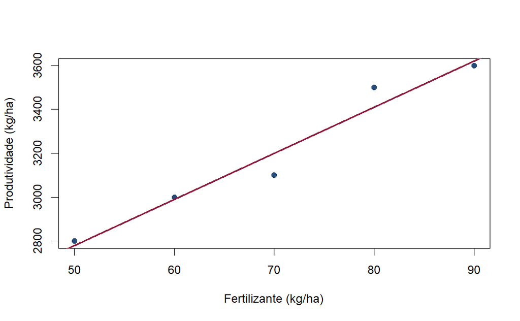

```r
# Diagrama de dispersão
plot(
  fertilizante,
  produtividade,
  pch = 19,
  col = "#274C77",
  xlab = "Fertilizante (kg/ha)",
  ylab = "Produtividade (kg/ha)"
)

# Reta de regressão apenas para auxiliar a visualização
abline(
  lm(produtividade ~ fertilizante),
  col = "#8B1E3F",
  lwd = 2
)
```

### 4.2 Correlação

A magnitude da covariância depende das unidades de medida. A **correlação** padroniza a covariância:

$$\operatorname{Corr}(X,Y)
=\frac{\operatorname{Cov}(X,Y)}
{\sqrt{\operatorname{Var}(X)}\sqrt{\operatorname{Var}(Y)}}.$$

Seu valor está sempre entre $-1$ e $1$.

```r
# Correlação calculada pela função do R
correlacao_amostral <- cor(fertilizante, produtividade)

# Cálculo a partir da covariância e dos desvios-padrão
correlacao_manual <- cov(fertilizante, produtividade) /
  (sd(fertilizante) * sd(produtividade))

c(
  funcao_cor = correlacao_amostral,
  calculo_manual = correlacao_manual
)
```

```
    funcao_cor calculo_manual
       0.97913        0.97913
```

### 4.3 Covariância zero não implica independência

Se duas variáveis são independentes e possuem momentos finitos, sua covariância é zero. A recíproca, entretanto, não é necessariamente verdadeira.

Considere $X\in\{-1,0,1\}$, com valores igualmente prováveis, e $Y=X^2$.

```r
# Valores possíveis de X e probabilidades
x_exemplo <- c(-1, 0, 1)
p_exemplo <- rep(1 / 3, 3)

# Y depende completamente de X
y_exemplo <- x_exemplo^2

# Momentos necessários para a covariância
ex <- sum(x_exemplo * p_exemplo)
ey <- sum(y_exemplo * p_exemplo)
exy <- sum(x_exemplo * y_exemplo * p_exemplo)

cov_xy <- exy - ex * ey

cov_xy
```

```
[1] 0
```

A covariância é zero, mas $Y$ é determinada por $X$. Portanto, ausência de correlação linear não significa ausência de relação entre as variáveis.

> **Por que isso importa para a Econometria?**  
> A inclinação da regressão linear simples depende da covariância entre $X$ e $Y$. Além disso, hipóteses de exogeneidade são frequentemente apresentadas por meio de restrições sobre a relação entre os regressores e o erro.

## 5. Esperança condicional

A **esperança condicional** de $Y$ dado $X=x$ é a média de $Y$ na subpopulação em que $X=x$:

$$\mathbb{E}(Y\mid X=x)
=\sum_y yP(Y=y\mid X=x),$$

no caso discreto.

Enquanto $\mathbb{E}(Y)$ é um único número, $\mathbb{E}(Y\mid X)$ é uma função de $X$. Ela associa uma média de $Y$ a cada valor possível de $X$.

### 5.1 Exemplo: irrigação e produtividade

Considere $I$, uma variável binária que indica o uso de irrigação:

$$I=\begin{cases}
1, & \text{se a propriedade utiliza irrigação};\\
0, & \text{caso contrário}.
\end{cases}$$

A distribuição conjunta de $I$ e da produtividade $Y$ é apresentada abaixo.

```r
# Distribuição conjunta de irrigação e produtividade
dados_conjuntos <- data.frame(
  irrigacao = c(0, 0, 0, 1, 1, 1),
  produtividade = c(2, 3, 4, 4, 5, 6),
  prob_conjunta = c(0.12, 0.36, 0.12, 0.10, 0.20, 0.10)
)

dados_conjuntos
```

| irrigacao | produtividade | prob_conjunta |
| --- | --- | --- |
| 0 | 2 | 0.12 |
| 0 | 3 | 0.36 |
| 0 | 4 | 0.12 |
| 1 | 4 | 0.10 |
| 1 | 5 | 0.20 |
| 1 | 6 | 0.10 |

```r
# Conferindo a soma das probabilidades conjuntas
sum(dados_conjuntos$prob_conjunta)
```

```
[1] 1
```

Primeiro, calculamos as probabilidades marginais dos dois grupos:

$$P(I=0)=0{,}60
\quad\text{e}\quad
P(I=1)=0{,}40.$$

```r
# Probabilidade total de cada grupo
prob_grupo <- tapply(
  dados_conjuntos$prob_conjunta,
  dados_conjuntos$irrigacao,
  sum
)

prob_grupo
```

```
  0   1
0.6 0.4
```

Para obter $\mathbb{E}(Y\mid I=i)$, ponderamos os valores de $Y$ pelas probabilidades condicionais dentro de cada grupo.

```r
# Numerador: soma de y vezes a probabilidade conjunta em cada grupo
numerador_condicional <- tapply(
  dados_conjuntos$produtividade * dados_conjuntos$prob_conjunta,
  dados_conjuntos$irrigacao,
  sum
)

# Média condicional em cada grupo
media_condicional <- numerador_condicional / prob_grupo

media_condicional
```

```
0 1
3 5
```

Assim,

$$\mathbb{E}(Y\mid I=0)=3
\quad\text{e}\quad
\mathbb{E}(Y\mid I=1)=5.$$

Isso não significa, por si só, que a irrigação cause um aumento de duas toneladas na produtividade. A diferença também pode refletir solo, clima, tecnologia, seleção das propriedades ou outras características.

### 5.2 Esperança condicional em uma amostra

Em dados amostrais, uma forma simples de estimar esperanças condicionais para uma variável categórica é calcular a média de cada grupo.

```r
# Exemplo de uma pequena amostra de propriedades
amostra_fazendas <- data.frame(
  irrigacao = c(0, 0, 0, 0, 1, 1, 1, 1),
  produtividade = c(2.7, 3.1, 3.0, 3.4, 4.5, 5.2, 4.8, 5.5)
)

# Média geral da produtividade
cat("Produtividade média entre as fazendas \n")
```

```
Produtividade média entre as fazendas
```

```r
mean(amostra_fazendas$produtividade)
```

```
[1] 4.025
```

```r
# Médias condicionais ao uso de irrigação
cat("Produtividade condicionada pelo regime \n")
```

```
Produtividade condicionada pelo regime
```

```r
tapply(
  amostra_fazendas$produtividade,
  amostra_fazendas$irrigacao,
  mean
)
```

```
   0    1
3.05 5.00
```

### 5.3 Propriedades importantes

Para constantes $a$ e $b$,

$$\mathbb{E}(a+bY\mid X)
=a+b\mathbb{E}(Y\mid X).$$

Se $g(X)$ é uma função conhecida de $X$, então:

$$\mathbb{E}[g(X)\mid X]=g(X),$$

e

$$\mathbb{E}[g(X)Y\mid X]
=g(X)\mathbb{E}(Y\mid X).$$

A função $g(X)$ pode ser colocada fora da esperança condicional porque, depois que condicionamos em $X$, seu valor é conhecido.

### 5.4 Esperança condicional como melhor preditor

Entre todas as funções de $X$, a esperança condicional minimiza o erro quadrático médio de previsão:

$$\mathbb{E}(Y\mid X)
=\arg\min_{g(X)}
\mathbb{E}\left[(Y-g(X))^2\right].$$

No exemplo amostral, podemos comparar duas previsões:

1. usar a média geral para todas as propriedades;
2. usar a média específica de cada grupo de irrigação.

```r
# Previsão 1: a mesma média geral para todas as propriedades
previsao_geral <- rep(
  mean(amostra_fazendas$produtividade),
  nrow(amostra_fazendas)
)

# Previsão 2: a média correspondente ao grupo da propriedade
medias_grupos <- tapply(
  amostra_fazendas$produtividade,
  amostra_fazendas$irrigacao,
  mean
)

previsao_condicional <- medias_grupos[
  as.character(amostra_fazendas$irrigacao)
]

# Erro quadrático médio de cada previsão
cat("EQM \n")
```

```
EQM
```

```r
eqm_geral <- mean(
  (amostra_fazendas$produtividade - previsao_geral)^2
)
eqm_geral
```

```
[1] 1.054375
```

```r
cat("EQM condicional \n")
```

```
EQM condicional
```

```r
eqm_condicional <- mean(
  (amostra_fazendas$produtividade - previsao_condicional)^2
)
eqm_condicional
```

```
[1] 0.10375
```

Neste exemplo, conhecer o grupo de irrigação permite construir uma previsão com menor erro quadrático médio.

> **Por que isso importa para a Econometria?**  
> A função de esperança condicional $\mathbb{E}(Y\mid X)$ descreve como a média de $Y$ varia com $X$. A regressão busca caracterizar ou aproximar essa relação. Uma diferença condicional, contudo, não deve ser interpretada automaticamente como efeito causal.

## 6. Lei das Expectativas Iteradas

Antes de apresentar a lei, é importante lembrar que a esperança condicional não é, em geral, um único número.

Para cada valor possível de $X$, podemos calcular uma média diferente de $Y$:

$$\mathbb{E}(Y\mid X=x).$$

Por exemplo, se $X$ indica o uso de irrigação, podemos calcular a produtividade média entre as propriedades irrigadas e a produtividade média entre as propriedades não irrigadas.

Assim, a expressão:

$$\mathbb{E}(Y\mid X)$$

é uma função de $X$: ela associa a cada valor de $X$ uma média condicional de $Y$. Como o próprio $X$ é uma variável aleatória, $\mathbb{E}(Y\mid X)$ também é uma variável aleatória.

A **Lei das Expectativas Iteradas** afirma que:

$$\mathbb{E}\left[\mathbb{E}(Y\mid X)\right]
=\mathbb{E}(Y).$$

A expressão contém duas operações de valor esperado:

- A expectativa interna, $\mathbb{E}(Y\mid X)$, calcula a média de $Y$ dentro de cada grupo definido por $X$.
- A expectativa externa, $\mathbb{E}[\mathbb{E}(Y\mid X)]$, calcula a média dessas médias condicionais, considerando a frequência ou a probabilidade de cada grupo.

Por isso, ela é chamada de Lei das Expectativas Iteradas: aplicamos a operação de valor esperado em duas etapas.

No caso de uma variável discreta, a lei pode ser escrita como:

$$\sum_x
\mathbb{E}(Y\mid X=x)P(X=x).$$

Em palavras, a média geral de $Y$ é uma média ponderada das médias condicionais, em que os pesos são as probabilidades dos diferentes valores de $X$.

### 6.1 Verificação no exemplo da irrigação

No exemplo anterior,

$$\begin{aligned}
\mathbb{E}(Y)
&=\mathbb{E}[\mathbb{E}(Y\mid I)]\\
&=\mathbb{E}(Y\mid I=0)P(I=0)
+\mathbb{E}(Y\mid I=1)P(I=1)\\
&=3(0{,}60)+5(0{,}40)\\
&=3{,}8.
\end{aligned}$$

```r
# Forma 1: valor esperado calculado diretamente da distribuição conjunta
esperanca_y_direta <- sum(
  dados_conjuntos$produtividade * dados_conjuntos$prob_conjunta
)

# Forma 2: média ponderada das esperanças condicionais
esperanca_y_iterada <- sum(media_condicional * prob_grupo)

c(
  calculo_direto = esperanca_y_direta,
  expectativas_iteradas = esperanca_y_iterada
)
```

```
       calculo_direto expectativas_iteradas
                  3.8                   3.8
```

A igualdade mostra que a média geral pode ser decomposta a partir das médias dos diferentes grupos da população.

### 6.2 Uma consequência importante

Se

$$\mathbb{E}(u\mid X)=0,$$

então, pela Lei das Expectativas Iteradas,

$$\mathbb{E}(u)
=\mathbb{E}[\mathbb{E}(u\mid X)]
=0.$$

Além disso,

$$\mathbb{E}(Xu)
=\mathbb{E}[\mathbb{E}(Xu\mid X)]
=\mathbb{E}[X\mathbb{E}(u\mid X)]
=0.$$

Portanto, a hipótese de média condicional zero implica média incondicional zero e ausência de correlação entre $X$ e $u$, quando os momentos existem. A recíproca não é garantida: $\mathbb{E}(Xu)=0$ é uma restrição mais fraca do que $\mathbb{E}(u\mid X)=0$.

> **Por que isso importa para a Econometria?**  
> A Lei das Expectativas Iteradas permite deduzir condições de momento a partir de hipóteses condicionais. Essa passagem será utilizada para estudar MQO, exogeneidade e propriedades dos estimadores.

## 7. Decomposição da variância

Uma extensão útil das ideias anteriores é a **Lei da Variância Total**:

$$\operatorname{Var}(Y)
=\mathbb{E}[\operatorname{Var}(Y\mid X)]
+\operatorname{Var}[\mathbb{E}(Y\mid X)].$$

A variância total de $Y$ pode ser dividida em:

- variação de $Y$ **dentro dos grupos** definidos por $X$;
- variação **entre as médias dos grupos**.

### 7.1 Aplicação ao exemplo da irrigação

```r
# Média geral de Y
media_y <- esperanca_y_direta

# Variância total de Y
variancia_total_y <- sum(
  (dados_conjuntos$produtividade - media_y)^2 *
    dados_conjuntos$prob_conjunta
)

# Variância condicional dentro de cada grupo
variancia_condicional <- sapply(c(0, 1), function(grupo) {
  selecionados <- dados_conjuntos$irrigacao == grupo

  y_grupo <- dados_conjuntos$produtividade[selecionados]
  p_conjunta_grupo <- dados_conjuntos$prob_conjunta[selecionados]
  p_condicional_grupo <- p_conjunta_grupo / sum(p_conjunta_grupo)
  media_grupo <- media_condicional[as.character(grupo)]

  sum((y_grupo - media_grupo)^2 * p_condicional_grupo)
})

# Média das variâncias condicionais: variação dentro dos grupos
variacao_dentro <- sum(variancia_condicional * prob_grupo)

# Variância das médias condicionais: variação entre os grupos
variacao_entre <- sum(
  (media_condicional - media_y)^2 * prob_grupo
)

c(
  variancia_total = variancia_total_y,
  variacao_dentro = variacao_dentro,
  variacao_entre = variacao_entre,
  soma_das_parcelas = variacao_dentro + variacao_entre
)
```

```
  variancia_total   variacao_dentro    variacao_entre soma_das_parcelas
             1.40              0.44              0.96              1.40
```

Essa decomposição ajuda a entender por que o conhecimento de $X$ pode melhorar a previsão de $Y$: quanto maior a variação entre as médias condicionais, maior é a parcela da variação de $Y$ que pode ser associada às diferenças entre os grupos definidos por $X$.

## 8. Uma ponte para o modelo de regressão

Considere o modelo populacional:

$$Y=\beta_0+\beta_1X+u,$$

com

$$\mathbb{E}(u\mid X)=0.$$

Aplicando a esperança condicional aos dois lados,

$$\begin{aligned}
\mathbb{E}(Y\mid X)
&=\mathbb{E}(\beta_0+\beta_1X+u\mid X)\\
&=\beta_0+\beta_1X+\mathbb{E}(u\mid X)\\
&=\beta_0+\beta_1X.
\end{aligned}$$

Assim, sob a hipótese de média condicional zero, a função de esperança condicional é linear em $X$.

### 8.1 Simulação

```r
# Tamanho da amostra
n_sim <- 1000

# Regressor: quantidade de insumo
x_sim <- rnorm(n_sim, mean = 10, sd = 2)

# Erro com média condicional zero
u_sim <- rnorm(n_sim, mean = 0, sd = 1.5)

# Resultado gerado pelo modelo populacional
y_sim <- 5 + 0.8 * x_sim + u_sim

# Verificações amostrais aproximadas
c(
  media_erro = mean(u_sim),
  covariancia_x_erro = cov(x_sim, u_sim)
)
```

```
        media_erro covariancia_x_erro
       -0.01870307        -0.04311286
```

Na população simulada, os valores verdadeiros são $\beta_0=5$ e $\beta_1=0{,}8$. Podemos estimá-los por MQO.

```r
# Estimando uma regressão linear simples
modelo_simulado <- lm(y_sim ~ x_sim)

coef(modelo_simulado)
```

```
(Intercept)       x_sim
  5.0930772   0.7889255
```

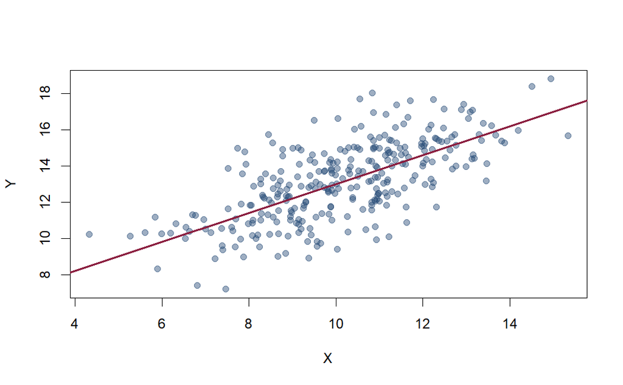

```r
# Exibindo somente parte das observações para facilitar a visualização
indices <- sample(seq_len(n_sim), size = 300)

plot(
  x_sim[indices],
  y_sim[indices],
  pch = 19,
  col = rgb(39 / 255, 76 / 255, 119 / 255, 0.45),
  xlab = "X",
  ylab = "Y"
)

# Função de esperança condicional verdadeira
abline(a = 5, b = 0.8, col = "#8B1E3F", lwd = 2)
```

## 9. Síntese dos principais conceitos

| Conceito | Definição ou resultado principal |
| --- | --- |
| Valor esperado | $\mathbb{E}(X)=\sum_x xP(X=x)$ |
| Segundo momento | $\mathbb{E}(X^2)=\sum_x x^2P(X=x)$ |
| Variância | $\operatorname{Var}(X)=\mathbb{E}(X^2)-[\mathbb{E}(X)]^2$ |
| Covariância | $\operatorname{Cov}(X,Y)=\mathbb{E}(XY)-\mathbb{E}(X)\mathbb{E}(Y)$ |
| Correlação | $\operatorname{Corr}(X,Y)=\operatorname{Cov}(X,Y)/(\sigma_X\sigma_Y)$ |
| Esperança condicional | Média de $Y$ na subpopulação definida por $X$ |
| Expectativas iteradas | $\mathbb{E}[\mathbb{E}(Y\mid X)]=\mathbb{E}(Y)$ |
| Variância total | $\operatorname{Var}(Y)=\mathbb{E}[\operatorname{Var}(Y\mid X)]+\operatorname{Var}[\mathbb{E}(Y\mid X)]$ |

# Considerações finais

Os conceitos revisados neste material formam a base probabilística da Econometria. O valor esperado descreve o centro de uma distribuição; a variância caracteriza sua dispersão; a covariância mede associação linear; e a esperança condicional descreve como a média de uma variável se modifica com a informação disponível.

A Lei das Expectativas Iteradas conecta médias condicionais e incondicionais e permite transformar hipóteses condicionais em condições de momento. Esses resultados serão retomados no estudo da função de esperança condicional, do melhor preditor linear e do método de mínimos quadrados ordinários.